# Welcome to my JUPYTER

### Flow of Content:

## 1 Introduction

- Info's about datasets

## 2. Librarys

- Importing Librarys
- Importing Dataset

## 3. Knowning the data

- 3.1 Looking the Type of Data
- 3.2 Shape of data
- 3.3 Null Numbers
- 3.4 Unique values
- 3.5 The first rows of our dataset

## 4. Exploring some Variables

- 4.1 Ploting some graphical and descriptive informations

## 6. Preprocess

- 6.1 Importing Librarys
- 6.2 Setting X and Y
- 6.3 Spliting the X and Y in train and test

# 7. Model

Logistic Regression

# 1 Introduction

Context

```
The original dataset contains 1000 entries with 20 categorial/symbolic attributes prepared by Prof. Hofmann. In this dataset, each entry represents a person who takes a credit by a bank. Each person is classified as good or bad credit risks according to the set of attributes. The link to the original dataset can be found below.
```

Content

```
It is almost impossible to understand the original dataset due to its complicated system of categories and symbols. Thus, I wrote a small Python script to convert it into a readable CSV file. Several columns are simply ignored, because in my opinion either they are not important or their descriptions are obscure. The selected attributes are:
```

Age (numeric)

Sex (text: male, female)

Job (numeric: 0 - unskilled and non-resident, 1 - unskilled and resident, 2 - skilled, 3 - highly skilled)

Housing (text: own, rent, or free)

Saving accounts (text - little, moderate, quite rich, rich)

Credit amount (numeric, in DM)

Duration (numeric, in month)

Purpose(text: car, furniture/equipment, radio/TV, domestic appliances, repairs, education, business, vacation/others

Risk (Value target - Good or Bad Risk)

# 2.Librarys:

Importing Librarys

Importing Dataset

```python
import pandas as pd,numpy as np,os
import matplotlib.pyplot as plt
import seaborn as sns
```

```python
os.chdir('D:\machine learning\Raw data')
```

```python
df_credit=pd.read_csv('german_credit_data.csv')
```

# 3. Knowning the data

3.1 Looking the Type of Data

3.2 Shape of data

3.3 Null Numbers

3.4 Unique values

3.5 The first rows of our dataset

```python
df_credit.isnull().sum()
```

```
Unnamed: 0            0
Age                   0
Sex                   0
Job                   0
Housing               0
Saving accounts     183
Checking_account    394
Credit_amount         0
Duration              0
Purpose               0
Risk                  0
dtype: int64
```

```python
df_credit.isnull().mean()*100
```

```
Unnamed: 0           0.0
Age                  0.0
Sex                  0.0
Job                  0.0
Housing              0.0
Saving accounts     18.3
Checking_account    39.4
Credit_amount        0.0
Duration             0.0
Purpose              0.0
Risk                 0.0
dtype: float64
```

```python
df_credit.info()
```

```
<class 'pandas.core.frame.DataFrame'>
RangeIndex: 1000 entries, 0 to 999
Data columns (total 11 columns):
 #   Column            Non-Null Count  Dtype
---  ------            --------------  -----
 0   Unnamed: 0        1000 non-null   int64
 1   Age               1000 non-null   int64
 2   Sex               1000 non-null   object
 3   Job               1000 non-null   int64
 4   Housing           1000 non-null   object
 5   Saving accounts   817 non-null    object
 6   Checking_account  606 non-null    object
 7   Credit_amount     1000 non-null   int64
 8   Duration          1000 non-null   int64
 9   Purpose           1000 non-null   object
 10  Risk              1000 non-null   object
dtypes: int64(5), object(6)
memory usage: 86.1+ KB
```

```python
df_credit.nunique()
```

```
Unnamed: 0          1000
Age                   53
Sex                    2
Job                    4
Housing                3
Saving accounts        4
Checking_account       3
Credit_amount        921
Duration              33
Purpose                8
Risk                   2
dtype: int64
```

```python
df_credit.head()
```

|  | Unnamed: 0 | Age | Sex | Job | Housing | Saving accounts | Checking_account | Credit_amount | Duration | Purpose | Risk |
| --- | --- | --- | --- | --- | --- | --- | --- | --- | --- | --- | --- |
| 0 | 0 | 67 | male | 2 | own | NaN | little | 1169 | 6 | radio/TV | good |
| 1 | 1 | 22 | female | 2 | own | little | moderate | 5951 | 48 | radio/TV | bad |
| 2 | 2 | 49 | male | 1 | own | little | NaN | 2096 | 12 | education | good |
| 3 | 3 | 45 | male | 2 | free | little | little | 7882 | 42 | furniture/equipment | good |
| 4 | 4 | 53 | male | 2 | free | little | little | 4870 | 24 | car | bad |

```python
df_credit.shape
```

```
(1000, 11)
```

#### null value

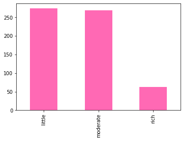

```python
df_credit['Checking_account'].value_counts().plot.bar(color='hotpink')
```

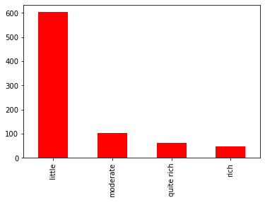

```python
df_credit['Saving accounts'].value_counts().plot.bar(color='r')
```

```python
def impute_nan(df,variable):
    most_frequent_category=df[variable].mode()[0]
    df[variable].fillna(most_frequent_category,inplace=True)
```

```python
   for feature in ['Checking_account','Saving accounts']:
        impute_nan(df_credit,feature)
```

```python
df_credit.isnull().sum()
```

```
Unnamed: 0          0
Age                 0
Sex                 0
Job                 0
Housing             0
Saving accounts     0
Checking_account    0
Credit_amount       0
Duration            0
Purpose             0
Risk                0
dtype: int64
```

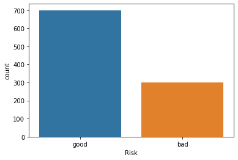

```python
sns.countplot('Risk', data=df_credit)
```

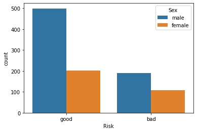

```python
sns.countplot('Risk', hue='Sex',data=df_credit)
```

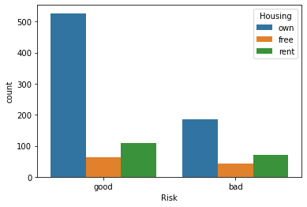

```python
sns.countplot('Risk', hue='Housing',data=df_credit )
```

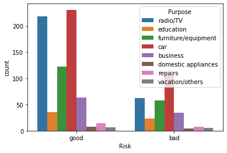

```python
sns.countplot('Risk', hue='Purpose',data=df_credit )
```

```python
df_credit.columns
```

```
Index(['Unnamed: 0', 'Age', 'Sex', 'Job', 'Housing', 'Saving accounts',
       'Checking_account', 'Credit_amount', 'Duration', 'Purpose', 'Risk'],
      dtype='object')
```

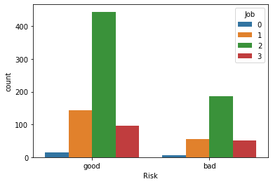

```python
sns.countplot('Risk', hue='Job',data=df_credit )
```

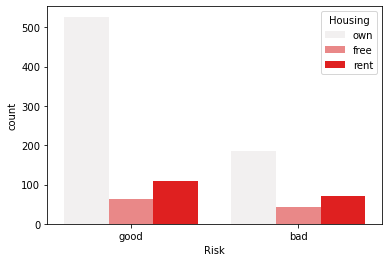

```python
sns.countplot("Risk",hue='Housing',data=df_credit,color='r')
```

```python
df_credit.info()
```

```
<class 'pandas.core.frame.DataFrame'>
RangeIndex: 1000 entries, 0 to 999
Data columns (total 11 columns):
 #   Column            Non-Null Count  Dtype
---  ------            --------------  -----
 0   Unnamed: 0        1000 non-null   int64
 1   Age               1000 non-null   int64
 2   Sex               1000 non-null   object
 3   Job               1000 non-null   int64
 4   Housing           1000 non-null   object
 5   Saving accounts   1000 non-null   object
 6   Checking_account  1000 non-null   object
 7   Credit_amount     1000 non-null   int64
 8   Duration          1000 non-null   int64
 9   Purpose           1000 non-null   object
 10  Risk              1000 non-null   object
dtypes: int64(5), object(6)
memory usage: 86.1+ KB
```

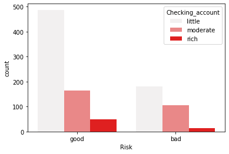

```python
sns.countplot("Risk",hue='Checking_account',data=df_credit,color="r")
```

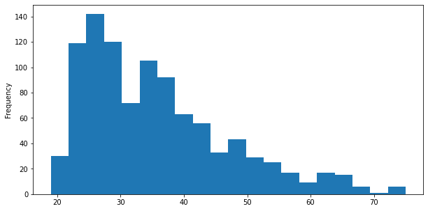

```python
df_credit['Age'].plot.hist(bins=20,figsize=(10,5))
```

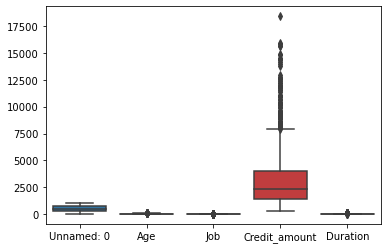

```python
sns.boxplot(data=df_credit)
```

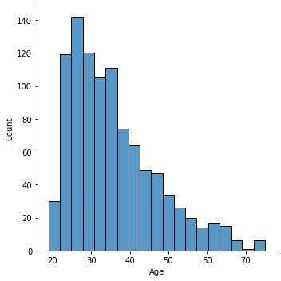

```python
sns.displot(df_credit['Age'])
```

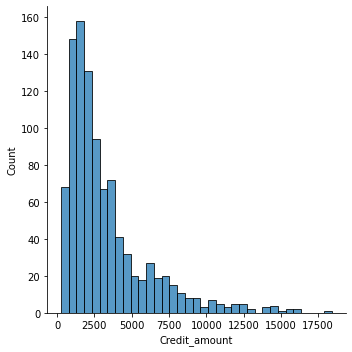

```python
sns.displot(df_credit['Credit_amount'])
```

```python
df_credit['Credit_amount'].describe()
```

```
count     1000.000000
mean      3271.258000
std       2822.736876
min        250.000000
25%       1365.500000
50%       2319.500000
75%       3972.250000
max      18424.000000
Name: Credit_amount, dtype: float64
```

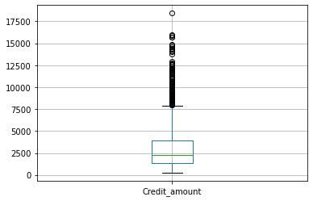

```python
df_credit.boxplot(column="Credit_amount")
```

```python
IQR=df_credit.Credit_amount.quantile(0.75)-df_credit.Credit_amount.quantile(0.25)
```

```python
lower_bridge=df_credit['Credit_amount'].quantile(0.25)-(IQR*1.5)
upper_bridge=df_credit['Credit_amount'].quantile(0.75)+(IQR*1.5)
print(lower_bridge), print(upper_bridge)
```

```
-2544.625
7882.375
```

```
(None, None)
```

```python
lower_bridge=df_credit['Credit_amount'].quantile(0.25)-(IQR*3)
upper_bridge=df_credit['Credit_amount'].quantile(0.75)+(IQR*3)
print(lower_bridge), print(upper_bridge)
```

```
-6454.75
11792.5
```

```
(None, None)
```

```python
data=df_credit.copy()
```

```python
data.loc[data['Credit_amount']>=11792.5,'Credit_amount']=11792.5
```

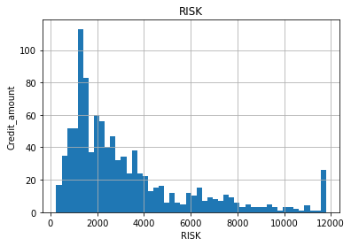

```python
figure=data.Credit_amount.hist(bins=50)
figure.set_title('RISK')
figure.set_xlabel('RISK')
figure.set_ylabel('Credit_amount')
```

```python
Risk_dum=pd.get_dummies(df_credit['Risk'], drop_first=True) [:5]
```

```python
df_credit.head()
```

|  | Unnamed: 0 | Age | Sex | Job | Housing | Saving accounts | Checking_account | Credit_amount | Duration | Purpose | Risk |
| --- | --- | --- | --- | --- | --- | --- | --- | --- | --- | --- | --- |
| 0 | 0 | 67 | male | 2 | own | little | little | 1169 | 6 | radio/TV | good |
| 1 | 1 | 22 | female | 2 | own | little | moderate | 5951 | 48 | radio/TV | bad |
| 2 | 2 | 49 | male | 1 | own | little | little | 2096 | 12 | education | good |
| 3 | 3 | 45 | male | 2 | free | little | little | 7882 | 42 | furniture/equipment | good |
| 4 | 4 | 53 | male | 2 | free | little | little | 4870 | 24 | car | bad |

```python
df_credit['Risk']=pd.get_dummies(df_credit['Risk'],dtype=int, drop_first=True)
```

```python
df_credit.head()
```

[output not shown]

```python
df_credit['Sex']=pd.get_dummies(df_credit['Sex'],dtype=int, drop_first=True)
```

```python
df_credit.info()
```

```
<class 'pandas.core.frame.DataFrame'>
RangeIndex: 1000 entries, 0 to 999
Data columns (total 11 columns):
 #   Column            Non-Null Count  Dtype
---  ------            --------------  -----
 0   Unnamed: 0        1000 non-null   int64
 1   Age               1000 non-null   int64
 2   Sex               1000 non-null   int32
 3   Job               1000 non-null   int64
 4   Housing           1000 non-null   object
 5   Saving accounts   1000 non-null   object
 6   Checking_account  1000 non-null   object
 7   Credit_amount     1000 non-null   int64
 8   Duration          1000 non-null   int64
 9   Purpose           1000 non-null   object
 10  Risk              1000 non-null   int32
dtypes: int32(2), int64(5), object(4)
memory usage: 78.2+ KB
```

```python
from sklearn import preprocessing
```

```python
label_encoder=preprocessing.LabelEncoder()
```

```python
df_credit['Housing']=label_encoder.fit_transform(df_credit['Housing'])
df_credit['Saving accounts']=label_encoder.fit_transform(df_credit['Saving accounts'])
df_credit['Checking_account']=label_encoder.fit_transform(df_credit['Checking_account'])
df_credit['Purpose']=label_encoder.fit_transform(df_credit['Purpose'])
```

```python
df_credit.head()
```

|  | Unnamed: 0 | Age | Sex | Job | Housing | Saving accounts | Checking_account | Credit_amount | Duration | Purpose | Risk |
| --- | --- | --- | --- | --- | --- | --- | --- | --- | --- | --- | --- |
| 0 | 0 | 67 | 1 | 2 | 1 | 0 | 0 | 1169 | 6 | 5 | 1 |
| 1 | 1 | 22 | 0 | 2 | 1 | 0 | 1 | 5951 | 48 | 5 | 0 |
| 2 | 2 | 49 | 1 | 1 | 1 | 0 | 0 | 2096 | 12 | 3 | 1 |
| 3 | 3 | 45 | 1 | 2 | 0 | 0 | 0 | 7882 | 42 | 4 | 1 |
| 4 | 4 | 53 | 1 | 2 | 0 | 0 | 0 | 4870 | 24 | 1 | 0 |

```python
x=df_credit.drop('Risk',axis=1,)
y=df_credit['Risk']
```

```python
from sklearn.model_selection import train_test_split
X_train, X_test, y_train, y_test = train_test_split(x, y, test_size=0.33, random_state=0)
```

```python
from sklearn.linear_model import LogisticRegression
classifier=LogisticRegression()
classifier.fit(X_train,y_train)
y_pred=classifier.predict(X_test)
y_pred1=classifier.predict_proba(X_test)
```

```python
from sklearn.metrics import accuracy_score,roc_auc_score
print("Accuracy_score: {}".format(accuracy_score(y_test,y_pred)))
print("roc_auc_score: {}".format(roc_auc_score(y_test,y_pred1[:,1])))
```

[output not shown]